# Risk Factor Analysis

## Outcome Variable

**Outcome Variable:** haz

## Predictor Variables

**Intervention Variable:** exclfeed6

**Adjustment Set:**

unadjusted

## Stratifying Variables

The analysis was stratified on these variable(s):

- agecat
- studyid
- country

## Data Summary

| agecat | studyid | country | exclfeed6 | n_cell | n |
| --- | --- | --- | --- | --- | --- |
| Birth | ki0047075b-MAL-ED | BANGLADESH | 1 | 56 | 231 |
| Birth | ki0047075b-MAL-ED | BANGLADESH | 0 | 175 | 231 |
| Birth | ki0047075b-MAL-ED | BRAZIL | 1 | 12 | 175 |
| Birth | ki0047075b-MAL-ED | BRAZIL | 0 | 163 | 175 |
| Birth | ki0047075b-MAL-ED | INDIA | 1 | 5 | 190 |
| Birth | ki0047075b-MAL-ED | INDIA | 0 | 185 | 190 |
| Birth | ki0047075b-MAL-ED | NEPAL | 1 | 11 | 170 |
| Birth | ki0047075b-MAL-ED | NEPAL | 0 | 159 | 170 |
| Birth | ki0047075b-MAL-ED | PERU | 1 | 10 | 256 |
| Birth | ki0047075b-MAL-ED | PERU | 0 | 246 | 256 |
| Birth | ki0047075b-MAL-ED | SOUTH AFRICA | 1 | 0 | 211 |
| Birth | ki0047075b-MAL-ED | SOUTH AFRICA | 0 | 211 | 211 |
| Birth | ki0047075b-MAL-ED | TANZANIA, UNITED REPUBLIC OF | 1 | 1 | 119 |
| Birth | ki0047075b-MAL-ED | TANZANIA, UNITED REPUBLIC OF | 0 | 118 | 119 |
| Birth | ki1000108-CMC-V-BCS-2002 | INDIA | 1 | 7 | 7 |
| Birth | ki1000108-CMC-V-BCS-2002 | INDIA | 0 | 0 | 7 |
| Birth | ki1000108-IRC | INDIA | 1 | 0 | 14 |
| Birth | ki1000108-IRC | INDIA | 0 | 14 | 14 |
| Birth | ki1000109-EE | PAKISTAN | 1 | 1 | 2 |
| Birth | ki1000109-EE | PAKISTAN | 0 | 1 | 2 |
| Birth | ki1000304b-SAS-CompFeed | INDIA | 1 | 48 | 50 |
| Birth | ki1000304b-SAS-CompFeed | INDIA | 0 | 2 | 50 |
| Birth | ki1101329-Keneba | GAMBIA | 1 | 484 | 1401 |
| Birth | ki1101329-Keneba | GAMBIA | 0 | 917 | 1401 |
| Birth | kiGH5241-JiVitA-3 | BANGLADESH | 1 | 15068 | 19082 |
| Birth | kiGH5241-JiVitA-3 | BANGLADESH | 0 | 4014 | 19082 |
| Birth | kiGH5241-JiVitA-4 | BANGLADESH | 1 | 617 | 767 |
| Birth | kiGH5241-JiVitA-4 | BANGLADESH | 0 | 150 | 767 |
| 6 months | ki0047075b-MAL-ED | BANGLADESH | 1 | 57 | 235 |
| 6 months | ki0047075b-MAL-ED | BANGLADESH | 0 | 178 | 235 |

[output cut: 64 more lines]

The following strata were considered:

- agecat: 24 months, studyid: ki0047075b-MAL-ED, country: BANGLADESH
- agecat: 24 months, studyid: ki0047075b-MAL-ED, country: BRAZIL
- agecat: 24 months, studyid: ki0047075b-MAL-ED, country: INDIA
- agecat: 24 months, studyid: ki0047075b-MAL-ED, country: NEPAL
- agecat: 24 months, studyid: ki0047075b-MAL-ED, country: PERU
- agecat: 24 months, studyid: ki0047075b-MAL-ED, country: SOUTH AFRICA
- agecat: 24 months, studyid: ki0047075b-MAL-ED, country: TANZANIA, UNITED REPUBLIC OF
- agecat: 24 months, studyid: ki1000108-CMC-V-BCS-2002, country: INDIA
- agecat: 24 months, studyid: ki1000108-IRC, country: INDIA
- agecat: 24 months, studyid: ki1017093b-PROVIDE, country: BANGLADESH
- agecat: 24 months, studyid: ki1101329-Keneba, country: GAMBIA
- agecat: 24 months, studyid: ki1113344-GMS-Nepal, country: NEPAL
- agecat: 24 months, studyid: ki1148112-LCNI-5, country: MALAWI
- agecat: 24 months, studyid: kiGH5241-JiVitA-3, country: BANGLADESH
- agecat: 24 months, studyid: kiGH5241-JiVitA-4, country: BANGLADESH
- agecat: 6 months, studyid: ki0047075b-MAL-ED, country: BANGLADESH
- agecat: 6 months, studyid: ki0047075b-MAL-ED, country: BRAZIL
- agecat: 6 months, studyid: ki0047075b-MAL-ED, country: INDIA
- agecat: 6 months, studyid: ki0047075b-MAL-ED, country: NEPAL
- agecat: 6 months, studyid: ki0047075b-MAL-ED, country: PERU
- agecat: 6 months, studyid: ki0047075b-MAL-ED, country: SOUTH AFRICA
- agecat: 6 months, studyid: ki0047075b-MAL-ED, country: TANZANIA, UNITED REPUBLIC OF
- agecat: 6 months, studyid: ki1000108-CMC-V-BCS-2002, country: INDIA
- agecat: 6 months, studyid: ki1000108-IRC, country: INDIA
- agecat: 6 months, studyid: ki1000109-EE, country: PAKISTAN
- agecat: 6 months, studyid: ki1000304b-SAS-CompFeed, country: INDIA
- agecat: 6 months, studyid: ki1000304b-SAS-FoodSuppl, country: INDIA
- agecat: 6 months, studyid: ki1017093b-PROVIDE, country: BANGLADESH
- agecat: 6 months, studyid: ki1101329-Keneba, country: GAMBIA
- agecat: 6 months, studyid: ki1113344-GMS-Nepal, country: NEPAL
- agecat: 6 months, studyid: ki1148112-LCNI-5, country: MALAWI
- agecat: 6 months, studyid: kiGH5241-JiVitA-3, country: BANGLADESH
- agecat: 6 months, studyid: kiGH5241-JiVitA-4, country: BANGLADESH
- agecat: Birth, studyid: ki0047075b-MAL-ED, country: BANGLADESH
- agecat: Birth, studyid: ki0047075b-MAL-ED, country: BRAZIL
- agecat: Birth, studyid: ki0047075b-MAL-ED, country: INDIA
- agecat: Birth, studyid: ki0047075b-MAL-ED, country: NEPAL
- agecat: Birth, studyid: ki0047075b-MAL-ED, country: PERU
- agecat: Birth, studyid: ki0047075b-MAL-ED, country: SOUTH AFRICA
- agecat: Birth, studyid: ki0047075b-MAL-ED, country: TANZANIA, UNITED REPUBLIC OF
- agecat: Birth, studyid: ki1000108-CMC-V-BCS-2002, country: INDIA
- agecat: Birth, studyid: ki1000108-IRC, country: INDIA
- agecat: Birth, studyid: ki1000109-EE, country: PAKISTAN
- agecat: Birth, studyid: ki1000304b-SAS-CompFeed, country: INDIA
- agecat: Birth, studyid: ki1101329-Keneba, country: GAMBIA
- agecat: Birth, studyid: kiGH5241-JiVitA-3, country: BANGLADESH
- agecat: Birth, studyid: kiGH5241-JiVitA-4, country: BANGLADESH

### Dropped Strata

- agecat: Birth, studyid: ki0047075b-MAL-ED, country: SOUTH AFRICA
- agecat: Birth, studyid: ki0047075b-MAL-ED, country: TANZANIA, UNITED REPUBLIC OF
- agecat: Birth, studyid: ki1000108-CMC-V-BCS-2002, country: INDIA
- agecat: Birth, studyid: ki1000108-IRC, country: INDIA
- agecat: Birth, studyid: ki1000109-EE, country: PAKISTAN
- agecat: Birth, studyid: ki1000304b-SAS-CompFeed, country: INDIA
- agecat: 6 months, studyid: ki0047075b-MAL-ED, country: SOUTH AFRICA
- agecat: 6 months, studyid: ki0047075b-MAL-ED, country: TANZANIA, UNITED REPUBLIC OF
- agecat: 6 months, studyid: ki1000108-CMC-V-BCS-2002, country: INDIA
- agecat: 6 months, studyid: ki1000108-IRC, country: INDIA
- agecat: 6 months, studyid: ki1000304b-SAS-FoodSuppl, country: INDIA
- agecat: 24 months, studyid: ki0047075b-MAL-ED, country: SOUTH AFRICA
- agecat: 24 months, studyid: ki0047075b-MAL-ED, country: TANZANIA, UNITED REPUBLIC OF
- agecat: 24 months, studyid: ki1000108-CMC-V-BCS-2002, country: INDIA
- agecat: 24 months, studyid: ki1000108-IRC, country: INDIA

## Methods Detail

We’re interested in the causal parameters $E[Y_a]$ for all values of $a \in \mathcal{A}$. These parameters represent the mean outcome if, possibly contrary to fact, we intervened to set all units to have $A=a$. Under the randomization and positivity assumptions, these are identified by the statistical parameters $\psi_a=E_W[E_{Y|A,W}(Y|A=a,W)]$. In addition, we’re interested in the mean of $Y$, $E[Y]$ under no intervention (the observed mean). We will estimate these parameters by using SuperLearner to fit the relevant likelihood factors – $E_{Y|A,W}(Y|A=a,W)$ and $p(A=a|W)$, and then updating our likelihood fit using a joint TMLE.

For unadjusted analyses ($W=\{\}$), initial likelihoods were estimated using Lrnr_glm to estimate the simple $E(Y|A)$ and Lrnr_mean to estimate $p(A)$. For adjusted analyses, a small library containing Lrnr_glmnet, Lrnr_xgboost, and Lrnr_mean was used.

Having estimated these parameters, we will then use the delta method to estimate relative risks and attributable risks relative to a prespecified baseline level of $A$.

# Results Detail

## Results Plots

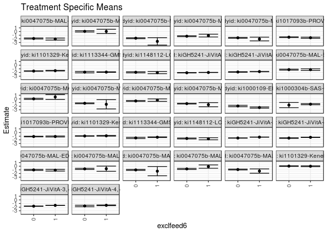

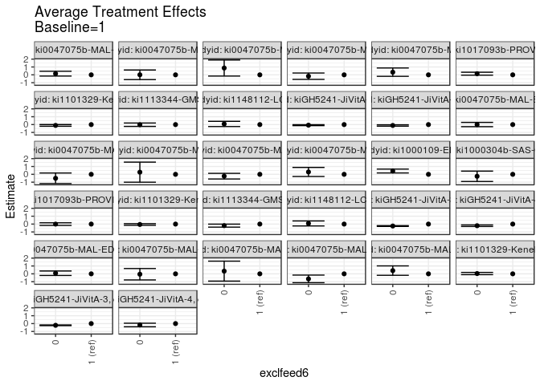

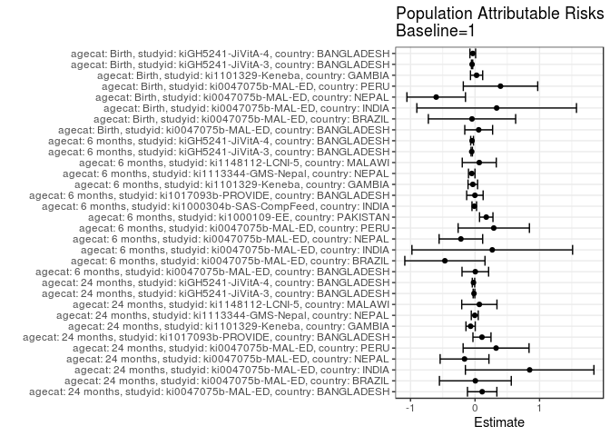

## Results Table

### Parameter: TSM

| agecat | studyid | country | intervention_level | baseline_level | estimate | ci_lower | ci_upper |
| --- | --- | --- | --- | --- | --- | --- | --- |
| Birth | ki0047075b-MAL-ED | BANGLADESH | 1 | NA | -1.0883929 | -1.3281384 | -0.8486473 |
| Birth | ki0047075b-MAL-ED | BANGLADESH | 0 | NA | -1.0136000 | -1.1672169 | -0.8599831 |
| Birth | ki0047075b-MAL-ED | BRAZIL | 1 | NA | -0.6791667 | -1.3864957 | 0.0281623 |
| Birth | ki0047075b-MAL-ED | BRAZIL | 0 | NA | -0.7298160 | -0.8949586 | -0.5646733 |
| Birth | ki0047075b-MAL-ED | INDIA | 1 | NA | -1.3600000 | -2.6219090 | -0.0980910 |
| Birth | ki0047075b-MAL-ED | INDIA | 0 | NA | -1.0160000 | -1.1632300 | -0.8687700 |
| Birth | ki0047075b-MAL-ED | NEPAL | 1 | NA | -0.0945455 | -0.5502841 | 0.3611932 |
| Birth | ki0047075b-MAL-ED | NEPAL | 0 | NA | -0.7381132 | -0.9029956 | -0.5732308 |
| Birth | ki0047075b-MAL-ED | PERU | 1 | NA | -1.3260000 | -1.9146249 | -0.7373751 |
| Birth | ki0047075b-MAL-ED | PERU | 0 | NA | -0.9151220 | -1.0316473 | -0.7985966 |
| Birth | ki1101329-Keneba | GAMBIA | 1 | NA | -0.0076446 | -0.1260217 | 0.1107325 |
| Birth | ki1101329-Keneba | GAMBIA | 0 | NA | 0.0287895 | -0.0541399 | 0.1117190 |
| Birth | kiGH5241-JiVitA-3 | BANGLADESH | 1 | NA | -1.5043775 | -1.5250722 | -1.4836827 |
| Birth | kiGH5241-JiVitA-3 | BANGLADESH | 0 | NA | -1.7226457 | -1.7647308 | -1.6805607 |
| Birth | kiGH5241-JiVitA-4 | BANGLADESH | 1 | NA | -1.4855754 | -1.5773703 | -1.3937805 |
| Birth | kiGH5241-JiVitA-4 | BANGLADESH | 0 | NA | -1.6654000 | -1.8733678 | -1.4574322 |
| 6 months | ki0047075b-MAL-ED | BANGLADESH | 1 | NA | -1.2182456 | -1.4535633 | -0.9829279 |
| 6 months | ki0047075b-MAL-ED | BANGLADESH | 0 | NA | -1.2126873 | -1.3490334 | -1.0763411 |
| 6 months | ki0047075b-MAL-ED | BRAZIL | 1 | NA | 0.5181250 | -0.1386917 | 1.1749417 |
| 6 months | ki0047075b-MAL-ED | BRAZIL | 0 | NA | 0.0122971 | -0.1325252 | 0.1571193 |
| 6 months | ki0047075b-MAL-ED | INDIA | 1 | NA | -1.4863889 | -2.7590210 | -0.2137568 |
| 6 months | ki0047075b-MAL-ED | INDIA | 0 | NA | -1.2122714 | -1.3302421 | -1.0943006 |
| 6 months | ki0047075b-MAL-ED | NEPAL | 1 | NA | -0.3403333 | -0.6809057 | 0.0002391 |
| 6 months | ki0047075b-MAL-ED | NEPAL | 0 | NA | -0.5745227 | -0.6929043 | -0.4561412 |
| 6 months | ki0047075b-MAL-ED | PERU | 1 | NA | -1.5995455 | -2.1651207 | -1.0339702 |
| 6 months | ki0047075b-MAL-ED | PERU | 0 | NA | -1.2969251 | -1.4058717 | -1.1879784 |
| 6 months | ki1000109-EE | PAKISTAN | 1 | NA | -2.3741284 | -2.5321982 | -2.2160586 |
| 6 months | ki1000109-EE | PAKISTAN | 0 | NA | -1.9546429 | -2.1431623 | -1.7661234 |
| 6 months | ki1000304b-SAS-CompFeed | INDIA | 1 | NA | -1.4578628 | -1.6049871 | -1.3107385 |
| 6 months | ki1000304b-SAS-CompFeed | INDIA | 0 | NA | -1.7063158 | -2.4149433 | -0.9976883 |
| 6 months | ki1017093b-PROVIDE | BANGLADESH | 1 | NA | -1.0850735 | -1.2247339 | -0.9454131 |
| 6 months | ki1017093b-PROVIDE | BANGLADESH | 0 | NA | -1.0877218 | -1.1779242 | -0.9975195 |
| 6 months | ki1101329-Keneba | GAMBIA | 1 | NA | -0.8984747 | -0.9872128 | -0.8097366 |
| 6 months | ki1101329-Keneba | GAMBIA | 0 | NA | -0.9484639 | -1.0075750 | -0.8893528 |
| 6 months | ki1113344-GMS-Nepal | NEPAL | 1 | NA | -1.2841089 | -1.3730507 | -1.1951671 |
| 6 months | ki1113344-GMS-Nepal | NEPAL | 0 | NA | -1.4805751 | -1.6493359 | -1.3118144 |
| 6 months | ki1148112-LCNI-5 | MALAWI | 1 | NA | -1.7051064 | -1.9955729 | -1.4146399 |
| 6 months | ki1148112-LCNI-5 | MALAWI | 0 | NA | -1.6259111 | -1.7571663 | -1.4946560 |
| 6 months | kiGH5241-JiVitA-3 | BANGLADESH | 1 | NA | -1.2591598 | -1.2841306 | -1.2341890 |
| 6 months | kiGH5241-JiVitA-3 | BANGLADESH | 0 | NA | -1.5047689 | -1.5515708 | -1.4579669 |
| 6 months | kiGH5241-JiVitA-4 | BANGLADESH | 1 | NA | -1.3116119 | -1.3532884 | -1.2699354 |
| 6 months | kiGH5241-JiVitA-4 | BANGLADESH | 0 | NA | -1.5194202 | -1.6108947 | -1.4279458 |
| 24 months | ki0047075b-MAL-ED | BANGLADESH | 1 | NA | -2.0637736 | -2.3352109 | -1.7923362 |
| 24 months | ki0047075b-MAL-ED | BANGLADESH | 0 | NA | -1.9157372 | -2.0547879 | -1.7766864 |
| 24 months | ki0047075b-MAL-ED | BRAZIL | 1 | NA | 0.0370000 | -0.5485351 | 0.6225351 |
| 24 months | ki0047075b-MAL-ED | BRAZIL | 0 | NA | 0.0423052 | -0.1321120 | 0.2167224 |
| 24 months | ki0047075b-MAL-ED | INDIA | 1 | NA | -2.6930000 | -3.7064117 | -1.6795883 |
| 24 months | ki0047075b-MAL-ED | INDIA | 0 | NA | -1.8272831 | -1.9537841 | -1.7007822 |
| 24 months | ki0047075b-MAL-ED | NEPAL | 1 | NA | -1.1116667 | -1.4962024 | -0.7271309 |
| 24 months | ki0047075b-MAL-ED | NEPAL | 0 | NA | -1.2859670 | -1.4122542 | -1.1596798 |
| 24 months | ki0047075b-MAL-ED | PERU | 1 | NA | -2.0556250 | -2.5736792 | -1.5375708 |
| 24 months | ki0047075b-MAL-ED | PERU | 0 | NA | -1.7157632 | -1.8378518 | -1.5936746 |
| 24 months | ki1017093b-PROVIDE | BANGLADESH | 1 | NA | -1.6934028 | -1.8521533 | -1.5346523 |
| 24 months | ki1017093b-PROVIDE | BANGLADESH | 0 | NA | -1.5504388 | -1.6477726 | -1.4531050 |
| 24 months | ki1101329-Keneba | GAMBIA | 1 | NA | -1.5033612 | -1.5893688 | -1.4173535 |
| 24 months | ki1101329-Keneba | GAMBIA | 0 | NA | -1.6075785 | -1.6745752 | -1.5405818 |
| 24 months | ki1113344-GMS-Nepal | NEPAL | 1 | NA | -1.8910000 | -1.9856651 | -1.7963349 |
| 24 months | ki1113344-GMS-Nepal | NEPAL | 0 | NA | -1.9075556 | -2.1012913 | -1.7138198 |
| 24 months | ki1148112-LCNI-5 | MALAWI | 1 | NA | -2.0273529 | -2.3204751 | -1.7342307 |
| 24 months | ki1148112-LCNI-5 | MALAWI | 0 | NA | -1.9459355 | -2.1034386 | -1.7884323 |
| 24 months | kiGH5241-JiVitA-3 | BANGLADESH | 1 | NA | -1.9959130 | -2.0256378 | -1.9661881 |
| 24 months | kiGH5241-JiVitA-3 | BANGLADESH | 0 | NA | -2.0700746 | -2.1258179 | -2.0143313 |
| 24 months | kiGH5241-JiVitA-4 | BANGLADESH | 1 | NA | -1.7521276 | -1.7941958 | -1.7100594 |
| 24 months | kiGH5241-JiVitA-4 | BANGLADESH | 0 | NA | -1.8640200 | -1.9450558 | -1.7829843 |

### Parameter: E(Y)

| agecat | studyid | country | intervention_level | baseline_level | estimate | ci_lower | ci_upper |
| --- | --- | --- | --- | --- | --- | --- | --- |
| Birth | ki0047075b-MAL-ED | BANGLADESH | NA | NA | -1.0317316 | -1.1618799 | -0.9015833 |
| Birth | ki0047075b-MAL-ED | BRAZIL | NA | NA | -0.7263429 | -0.8876385 | -0.5650472 |
| Birth | ki0047075b-MAL-ED | INDIA | NA | NA | -1.0250526 | -1.1724135 | -0.8776918 |
| Birth | ki0047075b-MAL-ED | NEPAL | NA | NA | -0.6964706 | -0.8552823 | -0.5376589 |
| Birth | ki0047075b-MAL-ED | PERU | NA | NA | -0.9311719 | -1.0458986 | -0.8164451 |
| Birth | ki1101329-Keneba | GAMBIA | NA | NA | 0.0162027 | -0.0517648 | 0.0841702 |
| Birth | kiGH5241-JiVitA-3 | BANGLADESH | NA | NA | -1.5502914 | -1.5696478 | -1.5309349 |
| Birth | kiGH5241-JiVitA-4 | BANGLADESH | NA | NA | -1.5207432 | -1.6058630 | -1.4356233 |
| 6 months | ki0047075b-MAL-ED | BANGLADESH | NA | NA | -1.2140355 | -1.3320337 | -1.0960372 |
| 6 months | ki0047075b-MAL-ED | BRAZIL | NA | NA | 0.0510207 | -0.0930194 | 0.1950608 |
| 6 months | ki0047075b-MAL-ED | INDIA | NA | NA | -1.2193606 | -1.3390323 | -1.0996890 |
| 6 months | ki0047075b-MAL-ED | NEPAL | NA | NA | -0.5595745 | -0.6727496 | -0.4463993 |
| 6 months | ki0047075b-MAL-ED | PERU | NA | NA | -1.3092999 | -1.4165606 | -1.2020392 |
| 6 months | ki1000109-EE | PAKISTAN | NA | NA | -2.2004704 | -2.3234073 | -2.0775336 |
| 6 months | ki1000304b-SAS-CompFeed | INDIA | NA | NA | -1.4697236 | -1.6333919 | -1.3060553 |
| 6 months | ki1017093b-PROVIDE | BANGLADESH | NA | NA | -1.0871041 | -1.1635539 | -1.0106543 |
| 6 months | ki1101329-Keneba | GAMBIA | NA | NA | -0.9331108 | -0.9823173 | -0.8839043 |
| 6 months | ki1113344-GMS-Nepal | NEPAL | NA | NA | -1.3352045 | -1.4146382 | -1.2557708 |
| 6 months | ki1148112-LCNI-5 | MALAWI | NA | NA | -1.6395956 | -1.7592633 | -1.5199278 |
| 6 months | kiGH5241-JiVitA-3 | BANGLADESH | NA | NA | -1.3104400 | -1.3338132 | -1.2870668 |
| 6 months | kiGH5241-JiVitA-4 | BANGLADESH | NA | NA | -1.3574771 | -1.3964060 | -1.3185482 |
| 24 months | ki0047075b-MAL-ED | BANGLADESH | NA | NA | -1.9532775 | -2.0781247 | -1.8284303 |
| 24 months | ki0047075b-MAL-ED | BRAZIL | NA | NA | 0.0418343 | -0.1253834 | 0.2090521 |
| 24 months | ki0047075b-MAL-ED | INDIA | NA | NA | -1.8466071 | -1.9736347 | -1.7195796 |
| 24 months | ki0047075b-MAL-ED | NEPAL | NA | NA | -1.2744493 | -1.3952297 | -1.1536689 |
| 24 months | ki0047075b-MAL-ED | PERU | NA | NA | -1.7294949 | -1.8488722 | -1.6101177 |
| 24 months | ki1017093b-PROVIDE | BANGLADESH | NA | NA | -1.5861179 | -1.6693668 | -1.5028689 |
| 24 months | ki1101329-Keneba | GAMBIA | NA | NA | -1.5721046 | -1.6251725 | -1.5190368 |
| 24 months | ki1113344-GMS-Nepal | NEPAL | NA | NA | -1.8951389 | -1.9810871 | -1.8091907 |
| 24 months | ki1148112-LCNI-5 | MALAWI | NA | NA | -1.9605820 | -2.1001715 | -1.8209925 |
| 24 months | kiGH5241-JiVitA-3 | BANGLADESH | NA | NA | -2.0122091 | -2.0399540 | -1.9844641 |
| 24 months | kiGH5241-JiVitA-4 | BANGLADESH | NA | NA | -1.7762003 | -1.8148628 | -1.7375378 |

### Parameter: ATE

| agecat | studyid | country | intervention_level | baseline_level | estimate | ci_lower | ci_upper |
| --- | --- | --- | --- | --- | --- | --- | --- |
| Birth | ki0047075b-MAL-ED | BANGLADESH | 1 | 1 | 0.0000000 | 0.0000000 | 0.0000000 |
| Birth | ki0047075b-MAL-ED | BANGLADESH | 0 | 1 | 0.0747929 | -0.2099457 | 0.3595315 |
| Birth | ki0047075b-MAL-ED | BRAZIL | 1 | 1 | 0.0000000 | 0.0000000 | 0.0000000 |
| Birth | ki0047075b-MAL-ED | BRAZIL | 0 | 1 | -0.0506493 | -0.7770007 | 0.6757021 |
| Birth | ki0047075b-MAL-ED | INDIA | 1 | 1 | 0.0000000 | 0.0000000 | 0.0000000 |
| Birth | ki0047075b-MAL-ED | INDIA | 0 | 1 | 0.3440000 | -0.9264688 | 1.6144688 |
| Birth | ki0047075b-MAL-ED | NEPAL | 1 | 1 | 0.0000000 | 0.0000000 | 0.0000000 |
| Birth | ki0047075b-MAL-ED | NEPAL | 0 | 1 | -0.6435678 | -1.1282160 | -0.1589195 |
| Birth | ki0047075b-MAL-ED | PERU | 1 | 1 | 0.0000000 | 0.0000000 | 0.0000000 |
| Birth | ki0047075b-MAL-ED | PERU | 0 | 1 | 0.4108780 | -0.1891698 | 1.0109259 |
| Birth | ki1101329-Keneba | GAMBIA | 1 | 1 | 0.0000000 | 0.0000000 | 0.0000000 |
| Birth | ki1101329-Keneba | GAMBIA | 0 | 1 | 0.0364342 | -0.1081011 | 0.1809694 |
| Birth | kiGH5241-JiVitA-3 | BANGLADESH | 1 | 1 | 0.0000000 | 0.0000000 | 0.0000000 |
| Birth | kiGH5241-JiVitA-3 | BANGLADESH | 0 | 1 | -0.2182683 | -0.2633556 | -0.1731809 |
| Birth | kiGH5241-JiVitA-4 | BANGLADESH | 1 | 1 | 0.0000000 | 0.0000000 | 0.0000000 |
| Birth | kiGH5241-JiVitA-4 | BANGLADESH | 0 | 1 | -0.1798246 | -0.4056166 | 0.0459674 |
| 6 months | ki0047075b-MAL-ED | BANGLADESH | 1 | 1 | 0.0000000 | 0.0000000 | 0.0000000 |
| 6 months | ki0047075b-MAL-ED | BANGLADESH | 0 | 1 | 0.0055583 | -0.2664061 | 0.2775228 |
| 6 months | ki0047075b-MAL-ED | BRAZIL | 1 | 1 | 0.0000000 | 0.0000000 | 0.0000000 |
| 6 months | ki0047075b-MAL-ED | BRAZIL | 0 | 1 | -0.5058279 | -1.1784212 | 0.1667653 |
| 6 months | ki0047075b-MAL-ED | INDIA | 1 | 1 | 0.0000000 | 0.0000000 | 0.0000000 |
| 6 months | ki0047075b-MAL-ED | INDIA | 0 | 1 | 0.2741175 | -1.0039707 | 1.5522057 |
| 6 months | ki0047075b-MAL-ED | NEPAL | 1 | 1 | 0.0000000 | 0.0000000 | 0.0000000 |
| 6 months | ki0047075b-MAL-ED | NEPAL | 0 | 1 | -0.2341894 | -0.5947497 | 0.1263709 |
| 6 months | ki0047075b-MAL-ED | PERU | 1 | 1 | 0.0000000 | 0.0000000 | 0.0000000 |
| 6 months | ki0047075b-MAL-ED | PERU | 0 | 1 | 0.3026204 | -0.2733525 | 0.8785933 |
| 6 months | ki1000109-EE | PAKISTAN | 1 | 1 | 0.0000000 | 0.0000000 | 0.0000000 |
| 6 months | ki1000109-EE | PAKISTAN | 0 | 1 | 0.4194856 | 0.1734660 | 0.6655052 |
| 6 months | ki1000304b-SAS-CompFeed | INDIA | 1 | 1 | 0.0000000 | 0.0000000 | 0.0000000 |
| 6 months | ki1000304b-SAS-CompFeed | INDIA | 0 | 1 | -0.2484530 | -0.9061015 | 0.4091955 |
| 6 months | ki1017093b-PROVIDE | BANGLADESH | 1 | 1 | 0.0000000 | 0.0000000 | 0.0000000 |
| 6 months | ki1017093b-PROVIDE | BANGLADESH | 0 | 1 | -0.0026483 | -0.1689056 | 0.1636090 |
| 6 months | ki1101329-Keneba | GAMBIA | 1 | 1 | 0.0000000 | 0.0000000 | 0.0000000 |
| 6 months | ki1101329-Keneba | GAMBIA | 0 | 1 | -0.0499892 | -0.1566127 | 0.0566343 |
| 6 months | ki1113344-GMS-Nepal | NEPAL | 1 | 1 | 0.0000000 | 0.0000000 | 0.0000000 |
| 6 months | ki1113344-GMS-Nepal | NEPAL | 0 | 1 | -0.1964662 | -0.3872300 | -0.0057024 |
| 6 months | ki1148112-LCNI-5 | MALAWI | 1 | 1 | 0.0000000 | 0.0000000 | 0.0000000 |
| 6 months | ki1148112-LCNI-5 | MALAWI | 0 | 1 | 0.0791953 | -0.2395502 | 0.3979408 |
| 6 months | kiGH5241-JiVitA-3 | BANGLADESH | 1 | 1 | 0.0000000 | 0.0000000 | 0.0000000 |
| 6 months | kiGH5241-JiVitA-3 | BANGLADESH | 0 | 1 | -0.2456091 | -0.2947343 | -0.1964839 |
| 6 months | kiGH5241-JiVitA-4 | BANGLADESH | 1 | 1 | 0.0000000 | 0.0000000 | 0.0000000 |
| 6 months | kiGH5241-JiVitA-4 | BANGLADESH | 0 | 1 | -0.2078083 | -0.3065389 | -0.1090776 |
| 24 months | ki0047075b-MAL-ED | BANGLADESH | 1 | 1 | 0.0000000 | 0.0000000 | 0.0000000 |
| 24 months | ki0047075b-MAL-ED | BANGLADESH | 0 | 1 | 0.1480364 | -0.1569445 | 0.4530173 |
| 24 months | ki0047075b-MAL-ED | BRAZIL | 1 | 1 | 0.0000000 | 0.0000000 | 0.0000000 |
| 24 months | ki0047075b-MAL-ED | BRAZIL | 0 | 1 | 0.0053052 | -0.6056552 | 0.6162656 |
| 24 months | ki0047075b-MAL-ED | INDIA | 1 | 1 | 0.0000000 | 0.0000000 | 0.0000000 |
| 24 months | ki0047075b-MAL-ED | INDIA | 0 | 1 | 0.8657169 | -0.1555597 | 1.8869934 |
| 24 months | ki0047075b-MAL-ED | NEPAL | 1 | 1 | 0.0000000 | 0.0000000 | 0.0000000 |
| 24 months | ki0047075b-MAL-ED | NEPAL | 0 | 1 | -0.1743003 | -0.5790425 | 0.2304419 |
| 24 months | ki0047075b-MAL-ED | PERU | 1 | 1 | 0.0000000 | 0.0000000 | 0.0000000 |
| 24 months | ki0047075b-MAL-ED | PERU | 0 | 1 | 0.3398618 | -0.1923842 | 0.8721078 |
| 24 months | ki1017093b-PROVIDE | BANGLADESH | 1 | 1 | 0.0000000 | 0.0000000 | 0.0000000 |
| 24 months | ki1017093b-PROVIDE | BANGLADESH | 0 | 1 | 0.1429640 | -0.0432499 | 0.3291778 |
| 24 months | ki1101329-Keneba | GAMBIA | 1 | 1 | 0.0000000 | 0.0000000 | 0.0000000 |
| 24 months | ki1101329-Keneba | GAMBIA | 0 | 1 | -0.1042173 | -0.2132397 | 0.0048050 |
| 24 months | ki1113344-GMS-Nepal | NEPAL | 1 | 1 | 0.0000000 | 0.0000000 | 0.0000000 |
| 24 months | ki1113344-GMS-Nepal | NEPAL | 0 | 1 | -0.0165556 | -0.2321826 | 0.1990715 |
| 24 months | ki1148112-LCNI-5 | MALAWI | 1 | 1 | 0.0000000 | 0.0000000 | 0.0000000 |
| 24 months | ki1148112-LCNI-5 | MALAWI | 0 | 1 | 0.0814175 | -0.2513405 | 0.4141754 |
| 24 months | kiGH5241-JiVitA-3 | BANGLADESH | 1 | 1 | 0.0000000 | 0.0000000 | 0.0000000 |
| 24 months | kiGH5241-JiVitA-3 | BANGLADESH | 0 | 1 | -0.0741616 | -0.1332649 | -0.0150583 |
| 24 months | kiGH5241-JiVitA-4 | BANGLADESH | 1 | 1 | 0.0000000 | 0.0000000 | 0.0000000 |
| 24 months | kiGH5241-JiVitA-4 | BANGLADESH | 0 | 1 | -0.1118924 | -0.1997972 | -0.0239877 |

### Parameter: PAR

| agecat | studyid | country | intervention_level | baseline_level | estimate | ci_lower | ci_upper |
| --- | --- | --- | --- | --- | --- | --- | --- |
| Birth | ki0047075b-MAL-ED | BANGLADESH | 1 | NA | 0.0566613 | -0.1590896 | 0.2724121 |
| Birth | ki0047075b-MAL-ED | BRAZIL | 1 | NA | -0.0471762 | -0.7237233 | 0.6293710 |
| Birth | ki0047075b-MAL-ED | INDIA | 1 | NA | 0.3349474 | -0.9021130 | 1.5720077 |
| Birth | ki0047075b-MAL-ED | NEPAL | 1 | NA | -0.6019251 | -1.0558418 | -0.1480085 |
| Birth | ki0047075b-MAL-ED | PERU | 1 | NA | 0.3948281 | -0.1818632 | 0.9715194 |
| Birth | ki1101329-Keneba | GAMBIA | 1 | NA | 0.0238473 | -0.0707600 | 0.1184547 |
| Birth | kiGH5241-JiVitA-3 | BANGLADESH | 1 | NA | -0.0459139 | -0.0554997 | -0.0363281 |
| Birth | kiGH5241-JiVitA-4 | BANGLADESH | 1 | NA | -0.0351678 | -0.0794933 | 0.0091578 |
| 6 months | ki0047075b-MAL-ED | BANGLADESH | 1 | NA | 0.0042102 | -0.2017887 | 0.2102090 |
| 6 months | ki0047075b-MAL-ED | BRAZIL | 1 | NA | -0.4671043 | -1.0884760 | 0.1542675 |
| 6 months | ki0047075b-MAL-ED | INDIA | 1 | NA | 0.2670283 | -0.9780186 | 1.5120751 |
| 6 months | ki0047075b-MAL-ED | NEPAL | 1 | NA | -0.2192411 | -0.5568667 | 0.1183844 |
| 6 months | ki0047075b-MAL-ED | PERU | 1 | NA | 0.2902456 | -0.2622211 | 0.8427122 |
| 6 months | ki1000109-EE | PAKISTAN | 1 | NA | 0.1736580 | 0.0696638 | 0.2776522 |
| 6 months | ki1000304b-SAS-CompFeed | INDIA | 1 | NA | -0.0118608 | -0.0472806 | 0.0235590 |
| 6 months | ki1017093b-PROVIDE | BANGLADESH | 1 | NA | -0.0020305 | -0.1295040 | 0.1254429 |
| 6 months | ki1101329-Keneba | GAMBIA | 1 | NA | -0.0346361 | -0.1085198 | 0.0392476 |
| 6 months | ki1113344-GMS-Nepal | NEPAL | 1 | NA | -0.0510956 | -0.1012330 | -0.0009582 |
| 6 months | ki1148112-LCNI-5 | MALAWI | 1 | NA | 0.0655108 | -0.1981815 | 0.3292031 |
| 6 months | kiGH5241-JiVitA-3 | BANGLADESH | 1 | NA | -0.0512802 | -0.0615587 | -0.0410017 |
| 6 months | kiGH5241-JiVitA-4 | BANGLADESH | 1 | NA | -0.0458652 | -0.0673001 | -0.0244303 |
| 24 months | ki0047075b-MAL-ED | BANGLADESH | 1 | NA | 0.1104961 | -0.1173134 | 0.3383055 |
| 24 months | ki0047075b-MAL-ED | BRAZIL | 1 | NA | 0.0048343 | -0.5518989 | 0.5615676 |
| 24 months | ki0047075b-MAL-ED | INDIA | 1 | NA | 0.8463929 | -0.1494933 | 1.8422790 |
| 24 months | ki0047075b-MAL-ED | NEPAL | 1 | NA | -0.1627827 | -0.5408219 | 0.2152566 |
| 24 months | ki0047075b-MAL-ED | PERU | 1 | NA | 0.3261301 | -0.1846965 | 0.8369566 |
| 24 months | ki1017093b-PROVIDE | BANGLADESH | 1 | NA | 0.1072849 | -0.0325474 | 0.2471173 |
| 24 months | ki1101329-Keneba | GAMBIA | 1 | NA | -0.0687435 | -0.1406995 | 0.0032125 |
| 24 months | ki1113344-GMS-Nepal | NEPAL | 1 | NA | -0.0041389 | -0.0580495 | 0.0497717 |
| 24 months | ki1148112-LCNI-5 | MALAWI | 1 | NA | 0.0667709 | -0.2061624 | 0.3397043 |
| 24 months | kiGH5241-JiVitA-3 | BANGLADESH | 1 | NA | -0.0162961 | -0.0292441 | -0.0033481 |
| 24 months | kiGH5241-JiVitA-4 | BANGLADESH | 1 | NA | -0.0240727 | -0.0427785 | -0.0053669 |